# Part II - (Ford GoBike Data Visual Exploration)

## by (Joshua Nnatus)

## Investigation Overview

> In this investigation, I wanted to look at the interesting relationship between distance and age, and how gender, distance covered (km) is distributed among those that use the bike for all trips.

## Dataset Overview

> The data consisted of bike trips and it's features of 183,412 trips. The features of the bike trips includes duration_sec, start_time, end_time, start_station_id, start_station_name, start_station_latitude, start_station_longitude, end_station_id, end_station_name, end_station_latitude, end_station_longitude, bike_id, user_type, member_birth_year, member_gender, bike_share_for_all_trip, and feature engineered features includes member_age, distance_km, start_time_weekday, start_time_hour, end_time_hour, and duration_minutes.

## Distribution of distance covered (km) for Ford Gobike trips

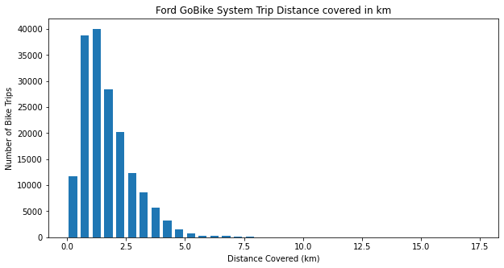

## Distribution of user member age for Ford Gobike trips

> The age of riders were from 20 to about 60+, using the guinness world records [LYNNEA SALVO](https://www.guinnessworldrecords.com/world-records/590324-oldest-person-to-cross-america-by-bicycle-n-s-female) at the age of 72 as a bench mark to remove outliers. The plot shows the distribution of age among the Ford GoBike riders

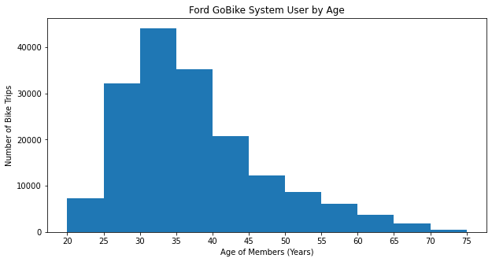

## Age vs Distance Covered (km)

> This show the relationship with Age and distance covered in km. The findings here shows a peak and decline, it is obvious that rider are can or that covers most distances are between the ages of 25 to 40. While most distance covered is from 0km to 4.5 km

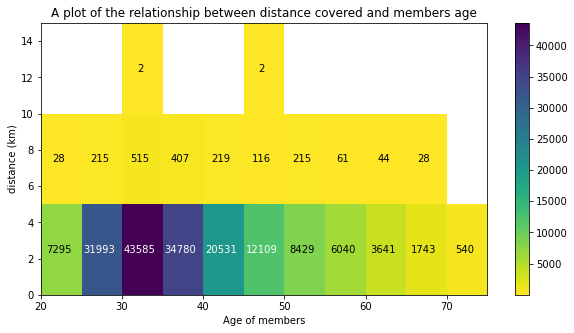

## Bike share for all trips and Average Distance Covered by Gender

> This show the relationship with member gender, Average distance covered and if they used the bike for all trip. This is an interesting plot that shows other genders trend to cover more average distances when they don't use the bike for all trips

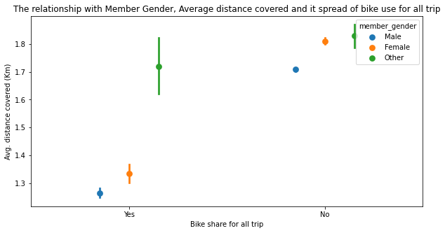